# Estimation: Introduction by Example

### Full Simulation

Run EKF on full trajectory

```python
def runEKF():
    P = P0
    x = x_start

    P_array = numpy.zeros((len(t), 4, 4))
    x_array = numpy.zeros((len(t), 4))
    P_array[0] = P
    x_array[0,:] = x_start
    for i in range(1, len(t)):
        x_plus = propagateEstimate(x)
        F = getF(x_plus)# + g
        H = getH(x_plus)
        P_plus = propagateCovariance(P, F)
        z_plus = expectedMeasurement(x_plus)
        Pzz_plus = propagatePzz(H, P_plus)
        Pxz_plus = propagatePxz(H, P_plus)
        K = getK(Pxz_plus, Pzz_plus)

        xnew = newEstimate(x_plus, K, z_plus, i)
        Pnew = newCovariance(P_plus, K, Pzz_plus)

        P_array[i] = Pnew
        x_array[i,:] = xnew

        P = Pnew
        x = xnew
    return x_array, P_array
ekfresults = runEKF()
ekf_traj, ekf_cov = ekfresults
```

### Results

Plot the results.

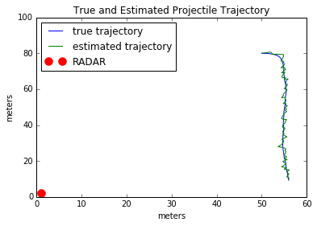

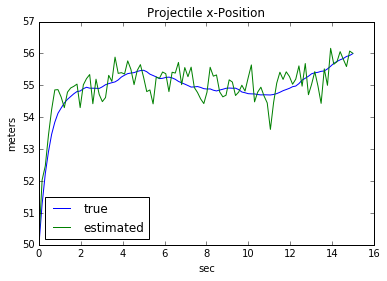

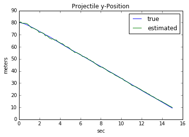

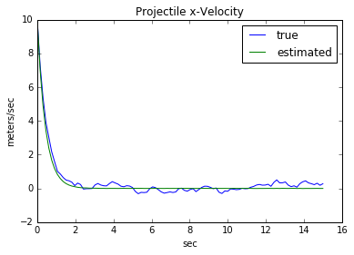

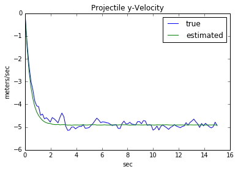

```python
def showEKFResults(trajectory, ekf_traj, ekf_cov):
    plt.plot(trajectory[:,0], trajectory[:,1], label='true trajectory')
    plt.plot(ekf_traj[:,0], ekf_traj[:,1], label='estimated trajectory')
    plt.title('True and Estimated Projectile Trajectory')
    plt.xlabel('meters'); plt.ylabel('meters')
    plt.plot(1.01,2,'r.', ms=20, label='RADAR')
    plt.legend(loc='best')
    plt.ylim([0,100])
    plt.show()
    plt.plot(t, trajectory[:,0], label='true')
    plt.plot(t, ekf_traj[:,0], label='estimated')
    plt.legend(loc='best')
    plt.title('Projectile x-Position')
    plt.xlabel('sec'); plt.ylabel('meters')
    plt.show()
    plt.plot(t, trajectory[:,1], label='true')
    plt.plot(t, ekf_traj[:,1], label='estimated')
    plt.legend(loc='best')
    plt.title('Projectile y-Position')
    plt.xlabel('sec'); plt.ylabel('meters')
    plt.show()
    plt.plot(t, trajectory[:,2], label='true')
    plt.plot(t, ekf_traj[:,2], label='estimated')
    plt.legend(loc='best')
    plt.title('Projectile x-Velocity')
    plt.xlabel('sec'); plt.ylabel('meters/sec')
    plt.show()
    plt.plot(t, trajectory[:,3], label='true')
    plt.plot(t, ekf_traj[:,3], label='estimated')
    plt.legend(loc='best')
    plt.title('Projectile y-Velocity')
    plt.xlabel('sec'); plt.ylabel('meters/sec')
    plt.show()
showEKFResults(trajectory, ekf_traj, ekf_cov)
```

### Final Thoughts

Pros: Work well on smooth problems, fast, lots of resources, well studied

Cons: Functions must be smooth, covariance must remain centered on propagated state, functions aren't changing too quickly (linear approximations must work well), process noise, measurement noise, and error estimates must be Gaussian and uncorrelated, requires analytical Jacobians (sometimes hard or impossible to form), diveregence risks.

## The Kalman Filter

### Intuition

The Kalman Filter is *exactly* the same as the EKF, except our system is now linear and time invariant. That means we don't need to calculate any Jacobians, and the filter will provide us with the no-kidding optimal estimate.

You may rightfully point out that almost no system that we care about is linear. So why would we ever really care about the Kalman filter? The answer is that a linear estimator is still extremely useful for nonlinear problems. Rather than estimating the states themselves (which are nonlinear), we estimate the *error states*. In other words, we have some nominal trajectory, and we run a Kalman filter on our deviation from that trajectory. Those are, in fact, linear problems.

### A New (Simpler) Dynamics Model

I'm going to steal the example from the Wikipedia page on Kalman filters:

*Consider a truck on frictionless, straight rails. Initially, the truck is stationary at position 0, but it is buffeted this way and that by random uncontrolled forces. We measure the position of the truck every Δt seconds, but these measurements are imprecise; we want to maintain a model of where the truck is and what its velocity is.*

#### Equations of Motion

Let us consider the position and velocity of a truck on a frictionless linear track that is being buffetted. We assume that between the $(k − 1)$ and $k$ timestep uncontrolled forces cause a constant acceleration of $a_k$ that is normally distributed, with mean 0 and standard deviation $\sigma_a$. The state at time $k$ is related to the state at time $k-1$ according to:

\begin{align} {\bf{x}}_{k+1} &= F{\bf{x}}_k + Ga_k \end{align}

where

\begin{align} F &= \begin{bmatrix} 1 & \Delta t\\ 0 & 1 \end{bmatrix}\\ G &= \begin{bmatrix} \frac{1}{2}\Delta t^2\\ \Delta t \end{bmatrix}\\ a_k &\sim \mathcal{N}(0,\sigma_a^2) \end{align}

We can rewrite the above system as:

\begin{align} {\bf{x}}_{k+1} &= F{\bf{x}}_k + {\bf{w}}_k \end{align}

where

\begin{align} {\bf{w}}_k &\sim \mathcal{N}(0,{\bf{Q}})\\ {\bf{Q}} &= GG^T \sigma_a^2\\ &= \begin{bmatrix} \frac{1}{4}\Delta t^4 & \frac{1}{2}\Delta t^3\\ \frac{1}{2} \Delta t^3 & \Delta t ^2 \end{bmatrix} \sigma_a^2 \end{align}

#### Simulation

Let us simulate this system, assuming that the truck starts with zero position and velocity.

```python
sigma_a = .5
x0 = numpy.array([0., 0.])
delta_t = .1
F = numpy.array([[1., delta_t],
                 [0., 1.]])
G = numpy.array([[.5*delta_t**2., delta_t]]).T
Q = numpy.array([[.25*delta_t**4., .5*delta_t**3.],
                 [.5*delta_t**3., delta_t**2.]])
N=100
```

```python
def truckSimulate(state, N=N):
    trajectory = numpy.zeros((N, 2))
    trajectory[0,:] = x0
    for i in range(1,N):
        new_state = (numpy.dot(F, numpy.array([trajectory[i-1,:]]).T) +
                     G*sigma_a*numpy.random.randn())
        trajectory[i,:] = new_state.T[0]
    return trajectory
truck = truckSimulate(x0)
```

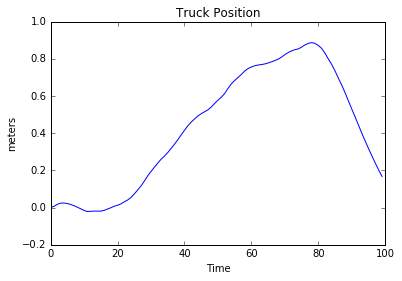

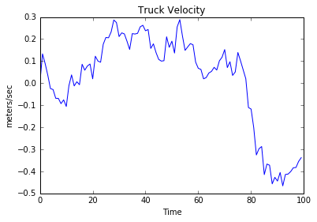

```python
def showTruck(truck):
    plt.plot(truck[:,0])
    plt.title('Truck Position')
    plt.xlabel('Time');plt.ylabel('meters')
    plt.show()
    plt.plot(truck[:,1])
    plt.title('Truck Velocity')
    plt.xlabel('Time');plt.ylabel('meters/sec')
    plt.show()
showTruck(truck)
```

### A New (Simpler) Measurement Model

#### The Model

Let us assume that we can measure the truck's position, but imperfectly. The error in our measurements is modeled as a zero-mean gaussian with standard deviation $\sigma_m$.

\begin{align} z_k &= H{\bf{x}}_k + v_k \end{align}

where:

\begin{align} H &= \begin{bmatrix} 1 & 0\end{bmatrix}\\ v_k &\sim \mathcal{N}(0, \sigma_m) \end{align}

Thus our measurement error covariance is given by:

\begin{align} R_k &= E\left[v_k v_k^T\right] = \sigma_m^2 \end{align}

#### Measurement Generation

We write a function that generates measurements associated with the stored truck trajectory.

```python
sigma_m = .3
H = numpy.array([[1., 0.]])
R = numpy.array([[sigma_m**2.]])
```

```python
def getTruckMeasurements():
    measurements = truck[:,0] + sigma_m*numpy.random.randn(N)
    return measurements
truck_meas = getTruckMeasurements()
```

#### Measurement Visualization

Plot these measurements.

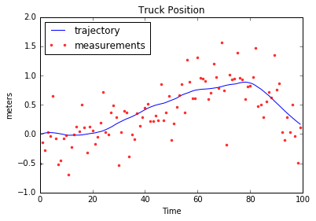

```python
def showTruckMeas(measurements, truck):
    plt.plot(truck[:,0], label='trajectory')
    plt.plot(measurements, 'r.', alpha=0.8, label='measurements')
    plt.title('Truck Position')
    plt.xlabel('Time');plt.ylabel('meters')
    plt.legend(loc='best')
    plt.show()
showTruckMeas(truck_meas, truck)
```

### Outline of Algorithm

Because this is identical to the EKF, just with a simpler dynamics model, I am going to skip the derivations. They're all the same.

#### Propagate Estimate

Our system matrics are now constant in time.

\begin{align} x^-_k &= F\hat{x}^+_{x-1} + F_uu_{k-1} \end{align}

#### Propagate Covariance

\begin{align} P_{k}^- &= FP_{k-1}^+F^T + Q \end{align}

#### Expected Measurement

\begin{align} \hat{z}_{k} &= Hx^-_k \end{align}

#### Innovation Covariance

\begin{align} P_{zz} = HP_k^-H^T + R \end{align}

#### State Innovation Covariance

\begin{align} P_{xz} &= P_k^- H^T \end{align}

#### Kalman Gain

\begin{align} K &= P_{xz}P_{zz}^{-1} \end{align}

#### Updated State Estimate

\begin{align} \hat{x}_k^+ &= x_k^- + K(z_k - \hat{z}_k) \end{align}

#### Updated Covariance

\begin{align} P_k^+ &= P_k^- - KHP_k^- \end{align}

### One Iteration

A walk through of one iteration of the Kalman Filter.

#### Initial state and covariance

\begin{align} \text{State Estimate} &= {\bf{\hat{x}}}(k)\\ \text{Coveriance Estimate} &= P(k)\\ \text{Process Noise} &\sim \mathcal{N}(0,Q(k))\\ \end{align}

```python
P0 = numpy.array([[.25, 0],
                  [0, .01]])
x_start = x0 + numpy.random.multivariate_normal(numpy.zeros(2), P0)
```

#### Predicted state estimate

\begin{align} x^-_k &= F\hat{x}^+_{x-1} + F_uu_{k-1} \end{align}

```python
def kalmanPredict(F, x):
    return numpy.dot(F, numpy.array([x]).T).T[0]
kx=kalmanPredict(F, x_start)
```

#### Predicted covariance

\begin{align} P_{k}^- &= FP_{k-1}^+F^T + Q \end{align}

```python
def kalmanCovPredict(F, P, Q):
    return numpy.dot(F, numpy.dot(P, F.T)) + Q
kp=kalmanCovPredict(F, P0, Q)
```

#### Innovation

\begin{align} \hat{z}_{k} &= Hx^-_k\\ \nu &= z_k - \hat{z}_k \end{align}

```python
def kalmanInnovation(x, time_index, H):
    return -numpy.dot(H, numpy.array([x]).T) + truck_meas[time_index]
vk=kalmanInnovation(kx,1,H)
```

#### Innovation covariance

\begin{align} P_{zz} = HP_k^-H^T + R \end{align}

```python
def kalmanPzz(R, H, P):
    return R + numpy.dot(H, numpy.dot(P, H.T))
pzzk=kalmanPzz(R, H, kp)
```

#### Optimal Kalman Gain

\begin{align} K &= P_{xz}P_{zz}^{-1} \end{align}

```python
def kalmanGain(P, H, Pzz):
    return numpy.dot(P, numpy.dot(H.T, pinv(Pzz)))
kK = kalmanGain(kp, H, pzzk)
```

#### Update State Estimate

\begin{align} \hat{x}_k^+ &= x_k^- + K(z_k - \hat{z}_k) \end{align}

```python
def kalmanStateUpdate(xm, K, v):
    return (numpy.array([xm]).T + numpy.dot(K, v)).T[0]
kalmanStateUpdate(kx, kK, vk)
```

```
array([-0.10568984, -0.07447142])
```

#### Update Covariance

\begin{align} P_k^+ &= P_k^- - KHP_k^- \end{align}

```python
def kalmanCovarianceUpdate(K, H, P, R):
    term = numpy.eye(2) - numpy.dot(K, H)
    first = numpy.dot(term, numpy.dot(P, term.T))
    second = numpy.dot(K, numpy.dot(R, K.T))
    return first+second
kalmanCovarianceUpdate(kK, H, kp, R)
```

```
array([[ 0.06618523,  0.00039691],
       [ 0.00039691,  0.01999338]])
```

### Full Simulation

Run the Kalman Filter over the full truck trajectory.

```python
def runKF():
    P = P0
    x = x_start

    P_array = numpy.zeros((len(t), 2, 2))
    x_array = numpy.zeros((len(t), 2))
    P_array[0] = P
    x_array[0,:] = x_start
    for i in range(1, len(t)):
        x_plus = kalmanPredict(F, x)
        P_plus = kalmanCovPredict(F, P, Q)
        v = kalmanInnovation(x_plus, i, H)
        Pzz = kalmanPzz(R, H, P_plus)
        K = kalmanGain(P_plus, H, Pzz)

        xnew = kalmanStateUpdate(x_plus, K, v)
        Pnew = kalmanCovarianceUpdate(K, H, P_plus, R)

        P_array[i] = Pnew
        x_array[i,:] = xnew

        P = Pnew
        x = xnew
    return x_array, P_array
kfresults = runKF()
kf_traj, kf_cov = kfresults
```

### Results

Plot the results.

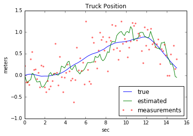

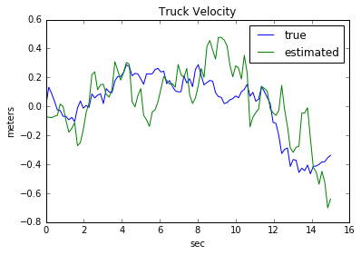

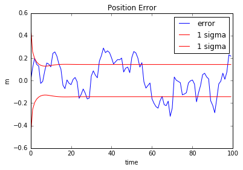

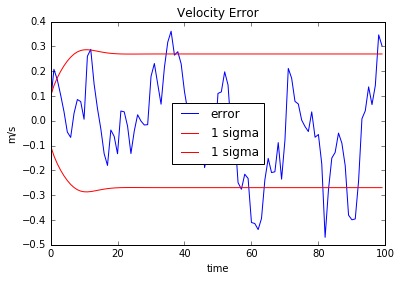

```python
def showKFResults(trajectory, kf_traj, kf_cov):
    plt.plot(t, trajectory[:,0], label='true')
    plt.plot(t, kf_traj[:,0], label='estimated')
    plt.plot(t, truck_meas, 'r.', alpha=.5, label='measurements')
    plt.legend(loc='best')
    plt.title('Truck Position')
    plt.xlabel('sec'); plt.ylabel('meters')
    plt.show()
    plt.plot(t, trajectory[:,1], label='true')
    plt.plot(t, kf_traj[:,1], label='estimated')
    plt.legend(loc='best')
    plt.title('Truck Velocity')
    plt.xlabel('sec'); plt.ylabel('meters')
    plt.show()

    x_err = trajectory[:,0] - kf_traj[:,0]
    xdot_err = trajectory[:,1] - kf_traj[:,1]

    xsig, ysig, xdotsig, ydotsig = [], [], [], []
    for i in range(len(pf_cov)):
        xsig.extend([numpy.sqrt(kf_cov[i][0][0])])
        xdotsig.extend([numpy.sqrt(kf_cov[i][1][1])])
    plt.plot(x_err, 'b-', label='error')
    plt.plot(1*numpy.array(xsig), 'r-', label='1 sigma')
    plt.plot(-1*numpy.array(xsig), 'r-', label='1 sigma')
    plt.legend(loc='best')
    plt.title('Position Error')
    plt.xlabel('time')
    plt.ylabel('m')
    plt.show()
    plt.plot(xdot_err, 'b-', label='error')
    plt.plot(1*numpy.array(xdotsig), 'r-', label='1 sigma')
    plt.plot(-1*numpy.array(xdotsig), 'r-', label='1 sigma')
    plt.legend(loc='best')
    plt.title('Velocity Error')
    plt.xlabel('time')
    plt.ylabel('m/s')
    plt.show()
showKFResults(truck, kf_traj, kf_cov)
```

## Common Gotcha's

1. Do one iteration, plot everything
2. Make sure your error is within covariance limits
3. Start with the simplest model that you can think of, add complexity incrementally
4. Keep an eye on the Kalman gain. If it's going to zero, the filter is ignoring sensors. If it's becoming large, the filter is ignoring dynamics.
5. The ratio of Q and R (process/measurement noise) is important. It tells the filter how much you trust your dynamic model vs. your sensors.
6. For Kalman filters, your noise *must* be zero-mean, Gaussian
7. Taking numerical derivatives in an EKF? Stop. Do a UKF instead.

## More Topics

1. Square root filtering
2. Information filtering
3. Iterated EKF's